# Tree_CART_RF_XGBoost

Huizi Yu

2/27/2020

In this Lab session, we will take a look at the following tree algorithms:

- Classification and Regression Tree
- Random Forest
- XGBoost

We would explore individual packages for these tree based algorithms, application of cross validatioin, and lastly the useful package “caret” that aggregates all these tree based algorithms as well as built-in cross validation.

```r
## Libraries for CART
library(tree)
library(rpart)
## Libraries for Random Forest
library(randomForest)
library(ranger) ## for faster implementation
## Libraries for XGboost
library(xgboost)
## Library for Lightgbm
library(lightgbm)
## Library for metric
library(Metrics)
## Library for CARET
library(caret)
library("Ckmeans.1d.dp")
```

## Loading in the data

```r
setwd("~/Dropbox/Projects/OSCR/ML_Lab1/Markdown")
football_train <- read.csv("~/Dropbox/Projects/OSCR/ML_Lab1/Datasets/football_train.csv")
football_test <- read.csv("~/Dropbox/Projects/OSCR/ML_Lab1/Datasets/football_test.csv")
football_answers <- read.csv("~/Dropbox/Projects/OSCR/ML_Lab1/Datasets/football_answers.csv")
```

## Tree Based Method (1) CART

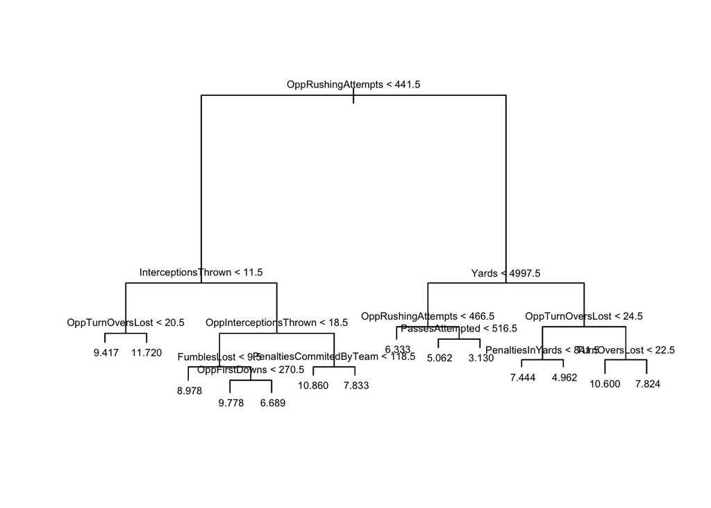

```r
tree_mod <- tree(Wins~. - ID, data = football_train)
plot(tree_mod)
text(tree_mod, cex = 0.6)
```

We interpret the tree diagram as following: For a team with opprushing attempt less than 441.5, interceptionsThrown less than 11.5, OppTurnOversLost less than 20.5, we predict the win to be 9.417.

As we can see, such tree model can be easily interpreted. But how does it perform in terms of predictability? We predict the testing set using this tree model.

```r
pred_tree <- predict(tree_mod, newdata = football_test)
rmse(actual = football_answers$Wins, predicted = pred_tree)
```

```
## [1] 2.327869
```

We found our prediction RMSE to be 2.32. Could it be possible that our model is overfitting the training data?

Remember from our previous post, we discussed CART’s propensity to overfit: Overfitting happens when a model memorizes its training data so well that it is learning noise on top of the signal. The CART algorithm will repeatedly partition data into smaller and smaller subsets until those final subsets contain only a small set of observations (1 or 2).